# python-api-covid19-pandas

## Uso de la API del Covid19 con Pandas

Vamos a hacer un ejercicio a partir de la siguiente URL: https://api.covid19api.com/countries

El término API es una abreviatura de Application Programming Interfaces, que en español significa interfaz de programación de aplicaciones. Se trata de un conjunto de definiciones y protocolos que se emplea para desarrollar e integrar el software de las aplicaciones, permitiendo la comunicación entre dos aplicaciones de software a través de un conjunto de reglas.

## Instalación librerías

```python
!pip install pandas
```

Recordemos que el símbolo de exclamación hacia abajo (!) significa que no estamos ejecutando Python sino bash

## Configuración de Pandas

Pandas es una librería de Phtyon especializada en el manejo y análisis de estructuras de datos, que incluye distintos tipos de estructuras de datos

Usamos la convención de pandas como pd

```python
import pandas as pd
```

## Crear variable

Vamos a crear la variable asignando la dirección al url del principio. Para ello, lo hacemos a través del signo = e incluimos la dirección del url entre comillas porque es una cadena de caracteres (string).

```python
url = 'https://api.covid19api.com/countries'
```

## Crear Dataframe

Los Dataframe por convención se definen como df. El Dataframe utiliza pandas y usamos una función que lee un json y dentro de ella, el valor de lo que queremos que lea (la url que he definido antes).

```python
df = pd.read_json(url)
```

```python
df
```

|  | Country | Slug | ISO2 |
| --- | --- | --- | --- |
| 0 | French Polynesia | french-polynesia | PF |
| 1 | Indonesia | indonesia | ID |
| 2 | Malta | malta | MT |
| 3 | Sao Tome and Principe | sao-tome-and-principe | ST |
| 4 | Haiti | haiti | HT |
| ... | ... | ... | ... |
| 243 | Myanmar | myanmar | MM |
| 244 | Turkey | turkey | TR |
| 245 | Western Sahara | western-sahara | EH |
| 246 | Pitcairn | pitcairn | PN |
| 247 | Tanzania, United Republic of | tanzania | TZ |

248 rows × 3 columns

## Exploración de la tabla

La función head funciona con 'int', por lo que devuelve en número de filas el valor del entero.

```python
df.head()
```

|  | Country | Slug | ISO2 |
| --- | --- | --- | --- |
| 0 | French Polynesia | french-polynesia | PF |
| 1 | Indonesia | indonesia | ID |
| 2 | Malta | malta | MT |
| 3 | Sao Tome and Principe | sao-tome-and-principe | ST |
| 4 | Haiti | haiti | HT |

```python
df.head(6)
```

|  | Country | Slug | ISO2 |
| --- | --- | --- | --- |
| 0 | French Polynesia | french-polynesia | PF |
| 1 | Indonesia | indonesia | ID |
| 2 | Malta | malta | MT |
| 3 | Sao Tome and Principe | sao-tome-and-principe | ST |
| 4 | Haiti | haiti | HT |
| 5 | Poland | poland | PL |

Al utilizar la función df.head() e introducir el número 6 dentro de los paréntesis, nos devuelve los seis primeros valores de la tabla (la cabecera)

Lo mismo ocurre si usamos df.tail(), pero en este caso nos devuelve los últimos valores (cola)

```python
df.tail(2)
```

|  | Country | Slug | ISO2 |
| --- | --- | --- | --- |
| 246 | Pitcairn | pitcairn | PN |
| 247 | Tanzania, United Republic of | tanzania | TZ |

La función df.info() nos proporciona información general sobre el DataFrame

```python
df.info()
```

```
<class 'pandas.core.frame.DataFrame'>
RangeIndex: 248 entries, 0 to 247
Data columns (total 3 columns):
 #   Column   Non-Null Count  Dtype
---  ------   --------------  -----
 0   Country  248 non-null    object
 1   Slug     248 non-null    object
 2   ISO2     248 non-null    object
dtypes: object(3)
memory usage: 5.9+ KB
```

```python
df['Country']
```

```
0                  French Polynesia
1                         Indonesia
2                             Malta
3             Sao Tome and Principe
4                             Haiti
                   ...
243                         Myanmar
244                          Turkey
245                  Western Sahara
246                        Pitcairn
247    Tanzania, United Republic of
Name: Country, Length: 248, dtype: object
```

```python
df['Country'][66]
```

```
'Somalia'
```

En este caso ponemos corchetes y no paréntesis porque es una lista. Lo hacemos para diferenciarlo con corchetes, llaves y paréntesis.

## Tiempo real

La URL que vamos a utilizar ahora es la siguiente, que ofrece datos a tiempo real para España: https://api.covid19api.com/country/spain/status/confirmed/live

Dado que durante todo este ejercicio solo emplearemos datos de España, llamaremos a esta dirección url_es (lo mismo haremos con df)

```python
url_es = 'https://api.covid19api.com/country/spain/status/confirmed/live'
df_es = pd.read_json(url_es)
df_es
```

|  | Country | CountryCode | Province | City | CityCode | Lat | Lon | Cases | Status | Date |
| --- | --- | --- | --- | --- | --- | --- | --- | --- | --- | --- |
| 0 | Spain | ES |  |  |  | 40.46 | -3.75 | 0 | confirmed | 2020-01-22 00:00:00+00:00 |
| 1 | Spain | ES |  |  |  | 40.46 | -3.75 | 0 | confirmed | 2020-01-23 00:00:00+00:00 |
| 2 | Spain | ES |  |  |  | 40.46 | -3.75 | 0 | confirmed | 2020-01-24 00:00:00+00:00 |
| 3 | Spain | ES |  |  |  | 40.46 | -3.75 | 0 | confirmed | 2020-01-25 00:00:00+00:00 |
| 4 | Spain | ES |  |  |  | 40.46 | -3.75 | 0 | confirmed | 2020-01-26 00:00:00+00:00 |
| ... | ... | ... | ... | ... | ... | ... | ... | ... | ... | ... |
| 814 | Spain | ES |  |  |  | 40.46 | -3.75 | 11627487 | confirmed | 2022-04-15 00:00:00+00:00 |
| 815 | Spain | ES |  |  |  | 40.46 | -3.75 | 11627487 | confirmed | 2022-04-16 00:00:00+00:00 |
| 816 | Spain | ES |  |  |  | 40.46 | -3.75 | 11627487 | confirmed | 2022-04-17 00:00:00+00:00 |
| 817 | Spain | ES |  |  |  | 40.46 | -3.75 | 11627487 | confirmed | 2022-04-18 00:00:00+00:00 |
| 818 | Spain | ES |  |  |  | 40.46 | -3.75 | 11627487 | confirmed | 2022-04-19 00:00:00+00:00 |

819 rows × 10 columns

```python
df_es.head()
```

|  | Country | CountryCode | Province | City | CityCode | Lat | Lon | Cases | Status | Date |
| --- | --- | --- | --- | --- | --- | --- | --- | --- | --- | --- |
| 0 | Spain | ES |  |  |  | 40.46 | -3.75 | 0 | confirmed | 2020-01-22 00:00:00+00:00 |
| 1 | Spain | ES |  |  |  | 40.46 | -3.75 | 0 | confirmed | 2020-01-23 00:00:00+00:00 |
| 2 | Spain | ES |  |  |  | 40.46 | -3.75 | 0 | confirmed | 2020-01-24 00:00:00+00:00 |
| 3 | Spain | ES |  |  |  | 40.46 | -3.75 | 0 | confirmed | 2020-01-25 00:00:00+00:00 |
| 4 | Spain | ES |  |  |  | 40.46 | -3.75 | 0 | confirmed | 2020-01-26 00:00:00+00:00 |

```python
df_es.columns
```

```
Index(['Country', 'CountryCode', 'Province', 'City', 'CityCode', 'Lat', 'Lon',
       'Cases', 'Status', 'Date'],
      dtype='object')
```

```python
df_es['Date'].head(1)
```

```
0   2020-01-22 00:00:00+00:00
Name: Date, dtype: datetime64[ns, UTC]
```

```python
df_es['Date'].tail(1)
```

[output not shown]

```python
df_es.describe()
```

[output not shown]

```python
df_es.set_index('Date')
```

[output not shown]

He convertido la columna de "fecha" en la columna de índice. La otra columna que quiero tener es la de "casos confirmados". Es decir, quiero una tabla que incluya ambos datos

```python
df_es.set_index('Date')['Cases']
```

[output not shown]

Se muestra también el número de casos (pero la tabla original no se ha tocado)

Para poder visualizar los datos en su totalidad, acudimos a la creación de un gráfico. Para ello, a lo anterior le digo que me lo pinte.

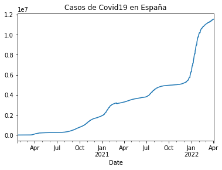

```python
df_es.set_index('Date')['Cases'].plot(title='Casos de Covid19 en España')
```

Al añadir lo último (title=...), le pongo el título que yo quiero al gráfico.

## Segundo país: Italia

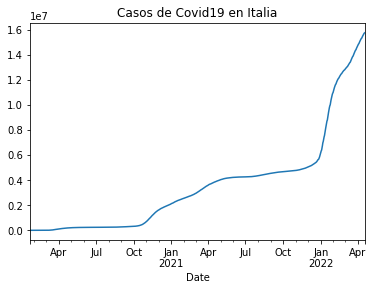

```python
url_it = 'https://api.covid19api.com/country/italy/status/confirmed/live'
df_it = pd.read_json(url_it)
df_it.set_index('Date')['Cases'].plot(title='Casos de Covid19 en Italia')
```

## Tercer país: México

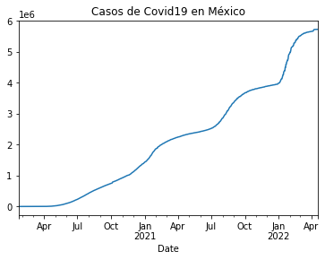

```python
url_mx = 'https://api.covid19api.com/country/mexico/status/confirmed/live'
df_mx = pd.read_json(url_mx)
df_mx.set_index('Date')['Cases'].plot(title='Casos de Covid19 en México')
```

## Comparación entre los tres países

Para obtener una información más completa, comparamos los tres países en un solo gráfico

```python
casos_es = df_es.set_index('Date')['Cases']
casos_it = df_it.set_index('Date')['Cases']
casos_mx = df_mx.set_index('Date')['Cases']
```

Vamos a usar la función .concat para crear una serie con los tres países y poder compararlos entre sí

```python
vs = pd.concat([casos_es,casos_it,casos_mx],axis=1)
vs
```

| Date | Cases | Cases | Cases |
| --- | --- | --- | --- |
| 2020-01-22 00:00:00+00:00 | 0 | 0 | 0 |
| 2020-01-23 00:00:00+00:00 | 0 | 0 | 0 |
| 2020-01-24 00:00:00+00:00 | 0 | 0 | 0 |
| 2020-01-25 00:00:00+00:00 | 0 | 0 | 0 |
| 2020-01-26 00:00:00+00:00 | 0 | 0 | 0 |
| ... | ... | ... | ... |
| 2022-04-15 00:00:00+00:00 | 11627487 | 15595302 | 5725476 |
| 2022-04-16 00:00:00+00:00 | 11627487 | 15659835 | 5726668 |
| 2022-04-17 00:00:00+00:00 | 11627487 | 15712088 | 5727668 |
| 2022-04-18 00:00:00+00:00 | 11627487 | 15730676 | 5727668 |
| 2022-04-19 00:00:00+00:00 | 11627487 | 15758002 | 5729270 |

819 rows × 3 columns

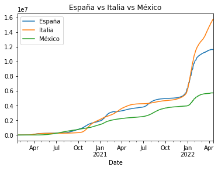

```python
vs.columns = ['España', 'Italia', 'México']
vs.plot(title='España vs Italia vs México')
```

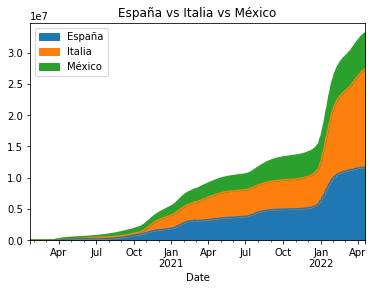

```python
vs.columns = ['España', 'Italia', 'México']
vs.plot(title="España vs Italia vs México", kind='area')
```

## Guardar el progreso

```python
vs.to_csv('esvsitvmx.csv')
```

Con el !, como explicamos previamente, indicamos que estamos ejecutando Bash y no Python. Mediante la función ls listamos y comprobamos si se ha guardado correctamente y dónde se ha guardado

```python
!ls
```

[output not shown]

Previamente, con csv, hemos guardado los datos. Sin embargo, también queremos guardar la gráfica como imagen. Por tanto, usamos el comando matplotlib (una librería que permite visualizar datos en Jupyter) y de ahí, guardamos en png

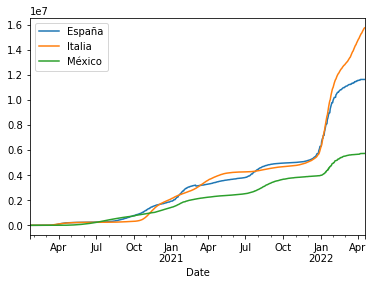

```python
import matplotlib.pyplot as plt
vs.plot()
plt.savefig('esvsitvmx.png')
```

```python
!ls
```

```
api-pandas-folium.ipynb  probando-con-r.ipynb		  Shared_Resources
esvsitvmx.csv		 python-api-covid19-pandas.ipynb  Untitled.ipynb
esvsitvmx.png		 python-pruebas.ipynb
```

Por último, comprobamos dónde se ha guardado y si hemos ejecutado correctamente el último comando